# Frequentist vs Bayesian

차서연

Dec 30, 2020

$$y \sim N(\mu, \sigma^2)$$

### Data

```r
data <- read.csv('velocity.csv', header = T)
head(data)
```

```
##       일자 요일   도로명 링크아이디       시점명          종점명 방향 거리
## 1 20200801   토 강남대로 1220021100   우성아파트          강남역 상행  586
## 2 20200801   토 강남대로 1220016200   우성아파트      뱅뱅사거리 하행  414
## 3 20200801   토   개포로 1220020500     대청초교          대청역 상행  862
## 4 20200801   토   개포로 1220018600       대청역      수서경찰서 상행  318
## 5 20200801   토   개포로 1220017200   수서경찰서    대모산입구역 상행  333
## 6 20200801   토   개포로 1220015600 대모산입구역 개포2동주민센터 상행  388
##   차선수 기능유형구분 도심.외곽구분 권역구분 X18시
## 1      4   주간선도로          외곽   강남구 18.74
## 2      4   주간선도로          외곽   강남구 27.39
## 3      2     기타도로          외곽   강남구 26.05
## 4      2     기타도로          외곽   강남구 27.22
## 5      2     기타도로          외곽   강남구 25.34
## 6      2     기타도로          외곽   강남구 27.30
```

```r
colnames(data)[13] <- "speed"
```

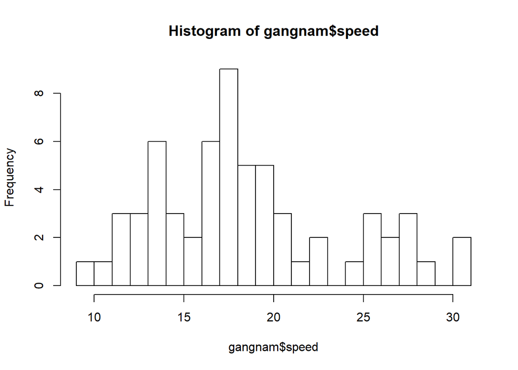

```r
gangnam <- data[data$도로명 == "강남대로",]
hist(gangnam$speed, breaks = 20)
```

### Frequentist inference

- t-test를 통한 평균 $\mu$의 검정

$$H_0 : \mu = 20 \ \ vs. \ H_1: \mu \neq 20$$

```r
t.test(gangnam$speed, mu = 20)
```

```
##
##  One Sample t-test
##
## data:  gangnam$speed
## t = -2.2525, df = 61, p-value = 0.0279
## alternative hypothesis: true mean is not equal to 20
## 95 percent confidence interval:
##  17.20432 19.83374
## sample estimates:
## mean of x
##  18.51903
```

- **p-value** = 0.0279
  - 평균 $\mu=20$일 확률이 0.0279다. **(X)**
  - *귀무가설이 참*일때, 즉 $\mu = 20$이라는 가정하에 위의 데이터가 관찰될 확률이 0.0279로 0.05보다 작으므로 귀무가설을 기각하고, $\mu = 20$이 아니라는 충분한 통계적 근거가 있다.
- **95% 신뢰구간**: (17.204 , 19.83374)
  - 모수 $\mu$가 (17.204 , 19.83374)에 포함될 확률이 95%다. **(X)**
  - 모수 $\mu$의 95% 신뢰구간:

$$(\bar{y} - t_{n-1}(0.025) \frac{s}{\sqrt{n}} \ , \ \bar{y} + t_{n-1}(0.025) \frac{s}{\sqrt{n}})$$

- 이러한 방식으로 여러 번 표본을 뽑아 신뢰구간을 구했을 때, 그중 95%는 모수 $\mu$를 포함할 것이다.
- 빈도주의 추론의 신뢰구간은 **repeated sampling** 관점에서 해석되는 것으로, 모수 $\mu$에 대한 어떤 확률적 진술(probability statement)도 하지 못한다.

```r
# Frequentist approach
# Confidence Interval of mu (data # = 62)
upper <- mean(gangnam$speed) + qt(0.975,61) * sd(gangnam$speed)/sqrt(62)
lower <- mean(gangnam$speed) - qt(0.975,61) * sd(gangnam$speed)/sqrt(62)
ci <- c(lower, upper)
ci
```

```
## [1] 17.20432 19.83374
```

### Bayesian inference

- 모수에 대한 직접적인 확률적 진술 가능 (probability statement about parameters)
- 모수가 갖는 불확실성을 확률적으로 수량화 (**quantify uncertatinty**)

```r
library(rstan)
```

### Stan code

```r
# bayes model
code1 <- '
data{
  int N; // number of obsverations
  real y[N]; // speed value
}

parameters{
  real mu; // mean
  real<lower=0> sigma; // standard deviation
}

model{
  y ~ normal(mu, sigma); // normal likelihood
}

generated quantities{
  real y_pred;
  y_pred = normal_rng(mu,sigma);
}
'
# compile models
model1 <- stan_model(model_code = code1, model_name="stanmodel")
```

### MCMC sampling

```r
list1 <- list(N=nrow(gangnam), y = gangnam$speed)
fit1 <- sampling(model1, data = list1, seed = 123)
fit1
```

```
## Inference for Stan model: stanmodel.
## 4 chains, each with iter=2000; warmup=1000; thin=1;
## post-warmup draws per chain=1000, total post-warmup draws=4000.
##
##           mean se_mean   sd    2.5%     25%     50%     75%   97.5% n_eff
## mu       18.52    0.01 0.67   17.23   18.08   18.51   18.97   19.89  2933
## sigma     5.29    0.01 0.48    4.44    4.95    5.25    5.58    6.32  3100
## y_pred   18.62    0.09 5.42    7.84   15.06   18.71   22.25   29.22  3938
## lp__   -131.78    0.02 1.00 -134.47 -132.14 -131.48 -131.08 -130.82  1628
##        Rhat
## mu        1
## sigma     1
## y_pred    1
## lp__      1
##
## Samples were drawn using NUTS(diag_e) at Wed Dec 30 11:31:58 2020.
## For each parameter, n_eff is a crude measure of effective sample size,
## and Rhat is the potential scale reduction factor on split chains (at
## convergence, Rhat=1).
```

### Posterior distribution of $\mu$ ($\mu$의 사후 분포)

```r
library(bayesplot)
```

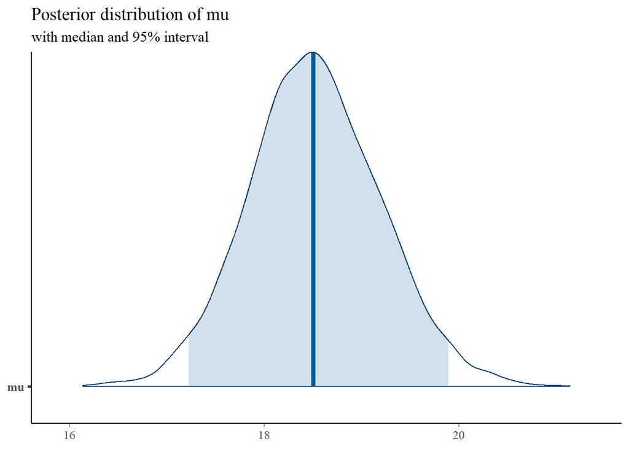

```r
mcmc_areas(fit1, "mu", prob = 0.95) +
  ggtitle("Posterior distribution of mu", "with median and 95% interval")
```

### 95% Bayesian credible interval(95% 베이즈 신뢰구간/신용구간) (↔︎ 신뢰구간)

- 평균 $\mu$의 95% 신용구간 = (17.23, 19.89)
- 모수 $\mu$가 (17.23, 19.89)에 포함될 확률이 95%다. **(O)**

→ 모수에 대한 직접적인 확률적 진술 가능 (probability statement about parameters)

→ 모수가 갖는 불확실성을 확률적으로 수량화 (**quantify uncertatinty**)

### Posterior probability(사후 확률) (↔︎ p-value)

```r
res <- extract(fit1)
str(res)
```

```
## List of 4
##  $ mu    : num [1:4000(1d)] 18.7 17.5 18.3 18.4 18.4 ...
##   ..- attr(*, "dimnames")=List of 1
##   .. ..$ iterations: NULL
##  $ sigma : num [1:4000(1d)] 5.61 4.99 5.17 5.37 5 ...
##   ..- attr(*, "dimnames")=List of 1
##   .. ..$ iterations: NULL
##  $ y_pred: num [1:4000(1d)] 21 16 12.9 18 22.1 ...
##   ..- attr(*, "dimnames")=List of 1
##   .. ..$ iterations: NULL
##  $ lp__  : num [1:4000(1d)] -131 -132 -131 -131 -131 ...
##   ..- attr(*, "dimnames")=List of 1
##   .. ..$ iterations: NULL
```

```r
sum(res$mu > 20)/4000
```

```
## [1] 0.01625
```

- $\mu >20$일 사후 확률이 0.0162다.